# More workflow

Rohan Alexander

18 September, 2026

# Quarto, websites, and PRs

## This week

- Quarto: one plain-text file, rendered to PDF, slides, or a website.
- Graphs with `ggplot2` and tables with `tinytable`, from a Parquet file that Python made.
- A website on GitHub Pages.
- Pull requests, reviews, and conflicts.

## A `.qmd` file has three parts

````markdown
---
title: "Shelter occupancy"
format: pdf
bibliography: references.bib
engine: markdown
---

Prose in Markdown, with a citation [@healy2019]
and a cross-reference to @fig-users.

```{r}
#| label: fig-users
#| fig-cap: "People in shelters each night"
ggplot(daily, aes(date, service_users)) + geom_line()
```
````

## Why this matters for the Donaldson paper

- Everything (tables, graphs) in the PDF comes from code that ran on the data 😎
- When we change the data we can render it again (or have a GitHub Actions to do that automatically), and then everything updates 😎
- A reader with the repo can check any figure 😎
- Pasted-in figures cannot be checked and go stale 😢

## You can use both Python and R

```
aggregate_shelter.py  --polars-->  data/shelter_daily.parquet  --arrow-->  02-demo.qmd (R)
```

- For instance, it’s common to use Python for scraping or interacting with an API: download, clean, aggregate, write Parquet.
- Then you could use R to make graphs and tables: `arrow::read_parquet()`, `ggplot2`, `tinytable`.
- Parquet keeps the types, so a date is still a date!

## `ggplot2` hello world!

```r
daily |>
  ggplot(aes(x = date, y = service_users, colour = sector)) +
  geom_line() +
  labs(x = "Date", y = "People", colour = "Sector") +
  theme_minimal()
```

- Data, then aesthetics (`aes`), then a geometry, then labels
- We use a “grammar” of graphics.

## `tinytable` hello world!

```r
latest |>
  tt(digits = 3) |>
  format_tt(j = "Occupancy", fn = scales::label_percent(0.1)) |>
  format_tt(escape = TRUE)
```

- Caption and cross-reference come from the chunk options `label: tbl-...` and `tbl-cap`.

## A website is just a type of doc

```yaml
project:
  type: website
  output-dir: docs
website:
  title: "Toronto shelters"
  navbar:
    left:
      - href: index.qmd
      - href: shelter.qmd
```

- `quarto render` builds every page into `docs/`.
- GitHub, Settings, Pages, deploy from `main`, folder `/docs`.
- `output-dir: docs` makes it easier to deploy from GitHub Pages.

## Pull requests

```bash
git checkout -b week_03_donoho_2017
git add . && git commit -m "Add slides on Donoho (2017)"
git push -u origin week_03_donoho_2017
```

- Then “Compare & pull request” on GitHub
- Someone else reads the diff and comments before it merges
- Nobody pushes to `main`

## Conflicts

```
<<<<<<< HEAD
- Week 3: Donoho (2017)
=======
- Week 3: Tukey (1977)
>>>>>>> week_03_donoho_2017
```

- Two people changed the same lines; Git asks you to choose
- Keep what you want, delete the three marker lines, `git add`, `git commit`
- Prevention: `git pull` before you start, and small PRs

# Overview

## Summary

- Graphs enable a familiarity with our data that is hard to get from any other method.
- We need to be comfortable with a variety of graph types, including:
  - bar charts;
  - scatterplots;
  - line plots; and
  - histograms.

## Why do we graph?

> Data display is critical to data analysis. Graphs allow us to explore data to see overall patterns and to see detailed behavior; no other approach can compete in revealing the structure of data so thoroughly. Graphs allow us to view complex mathematical models fitted to data, and they allow us to assess the validity of such models.

Cleveland (1994, 5)

## Realizing the potential of data visualization requires methods and basic principles

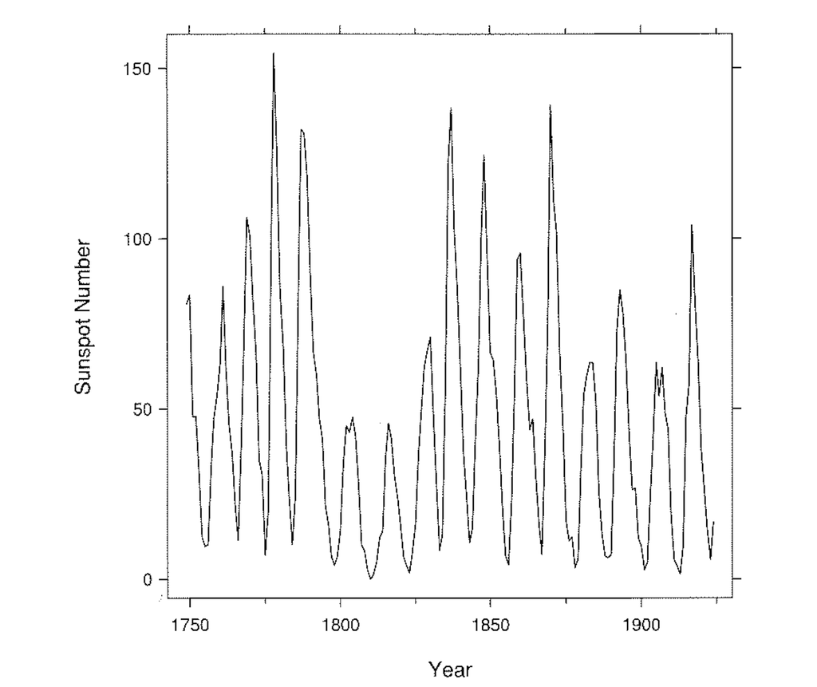

Figure 1.1 from Cleveland (1994, 4).

## But mostly involves thinking (hard) about the data, what we want to communicate, and to whom

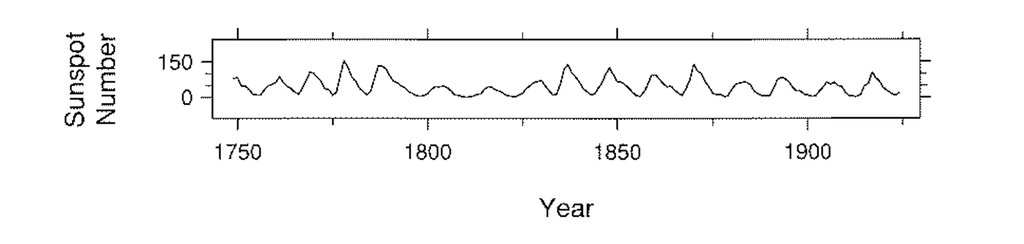

Figure 1.1 from Cleveland (1994, 4).

## Graphs preserve data

- Graphs allow us to explore all the information in the data.
- The most important objective of a graph is to convey as much of the actual data, and its context, as possible.

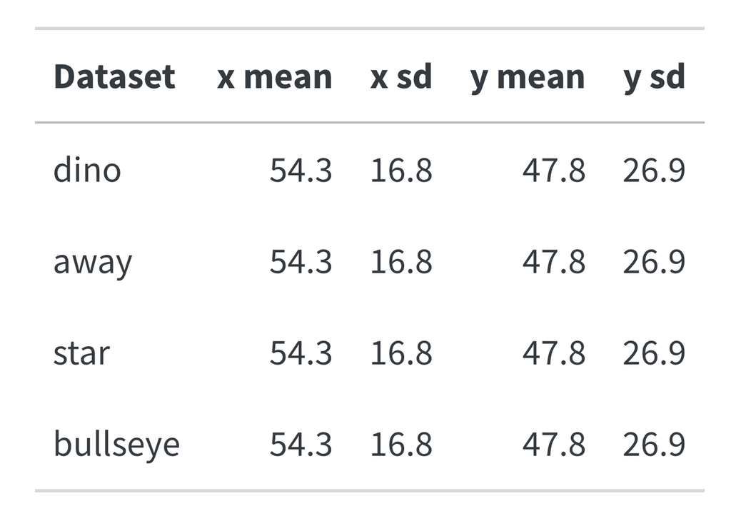

*Discussion: What do you think about each dataset?*

## Graphs preserve data

### They illustrate data in a way that other methods struggle to

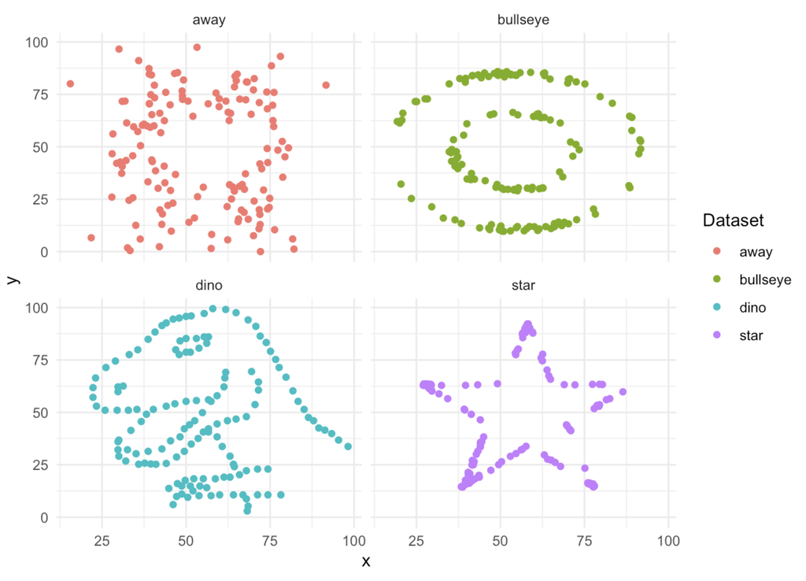

## Anscombe’s Quartet

### Mean and standard deviation

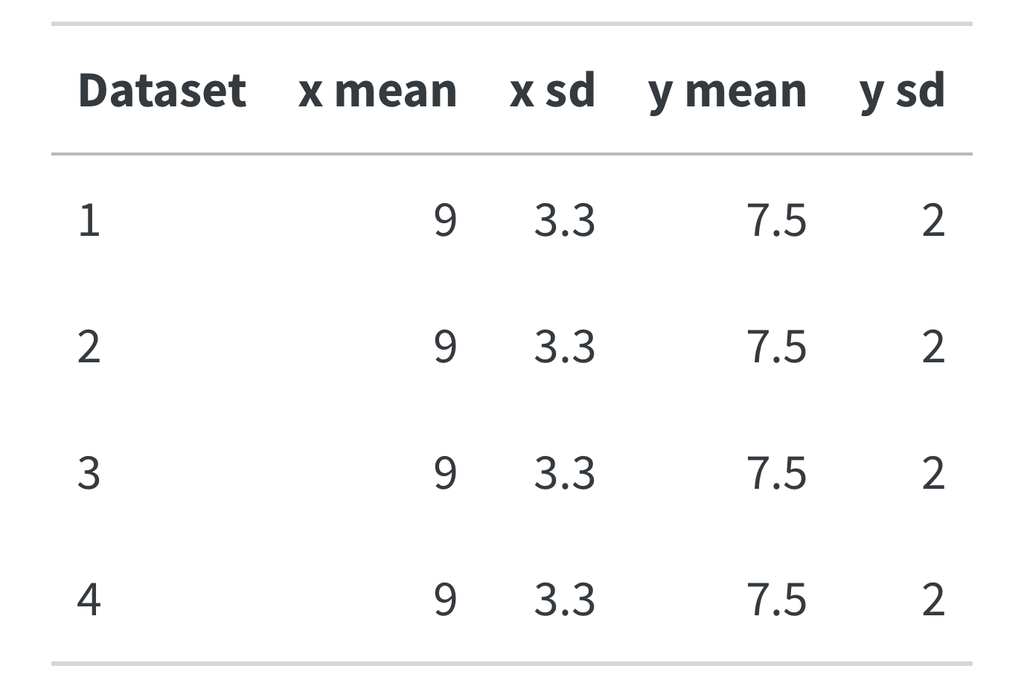

Mean and standard deviation for Anscombe’s quartet.

## Anscombe’s Quartet

### Graph

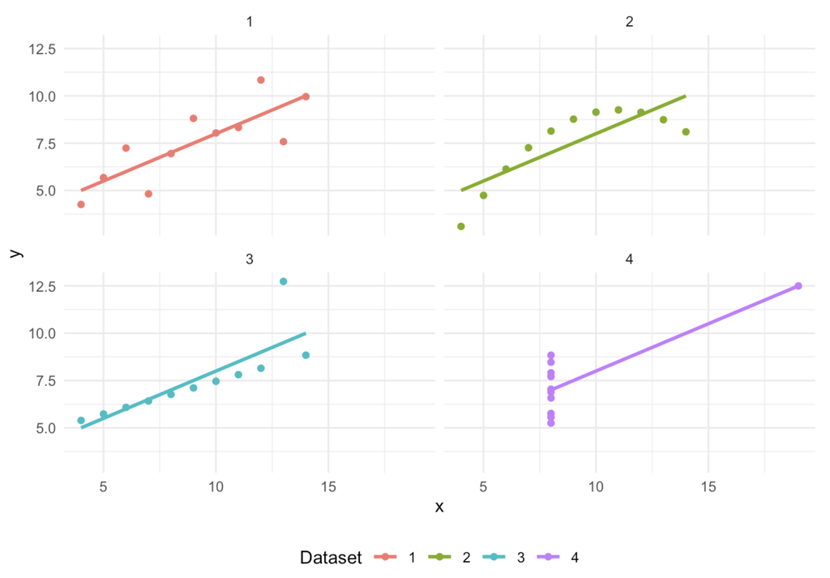

Recreation of Anscombe’s Quartet.

## What do we graph?

- Every variable of interest should be graphed in a way that every observation can be identified.
- Small datasets can be put into tables; large datasets can be sampled from.

*Discussion: What are some caveats from your own research?*

## Bar chart

- We typically use a bar chart when we have a categorical variable that we want to focus on.

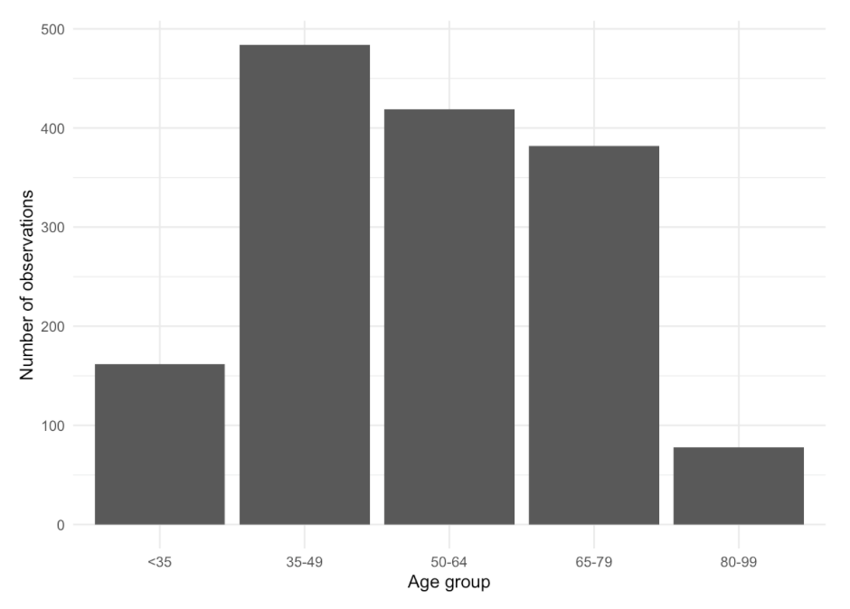

Distribution of age-groups in the 1997-2001 British Election Panel Study.

*Discussion: How might this affect our analysis?*

## Bar chart

### With facet and color

- We can use facets and color to focus on more than one variable.

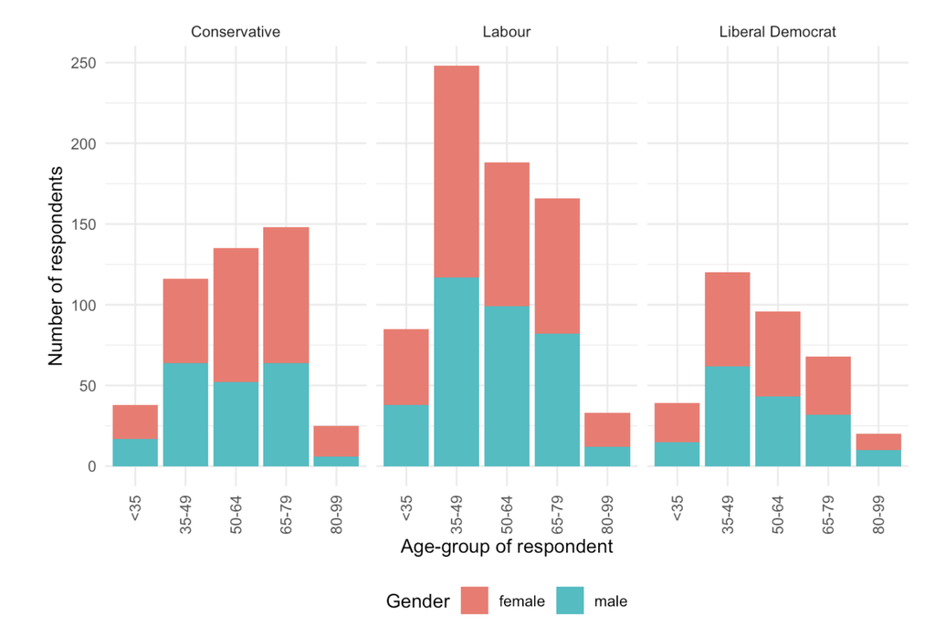

Distribution of age-group by gender, and vote preference, in the 1997-2001 British Election Panel Study.

## Scatterplots

- Scatterplots can be used to show the relationship between two numeric or continuous variables.

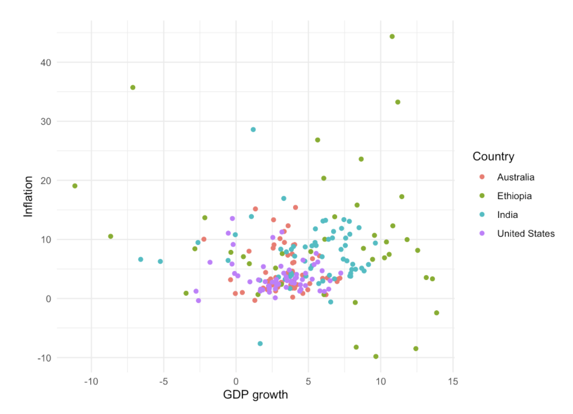

Relationship between inflation and GDP growth for Australia, Ethiopia, India, and the United States.

## Line plots

- We can use a line plot when we have variables that should be joined together, for instance, an economic time series.

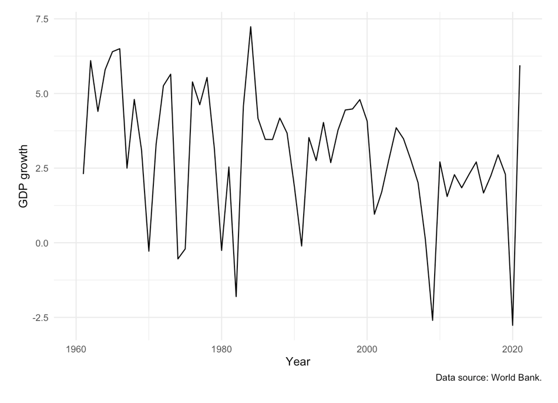

## Histograms

- A histogram is useful to show the shape of the distribution of a continuous variable.

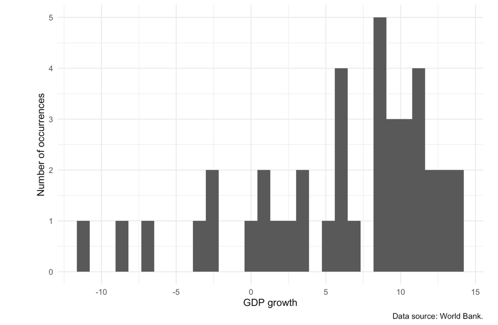

Distribution of GDP growth in Ethiopia (1960-2020)

## Histograms

### Bins

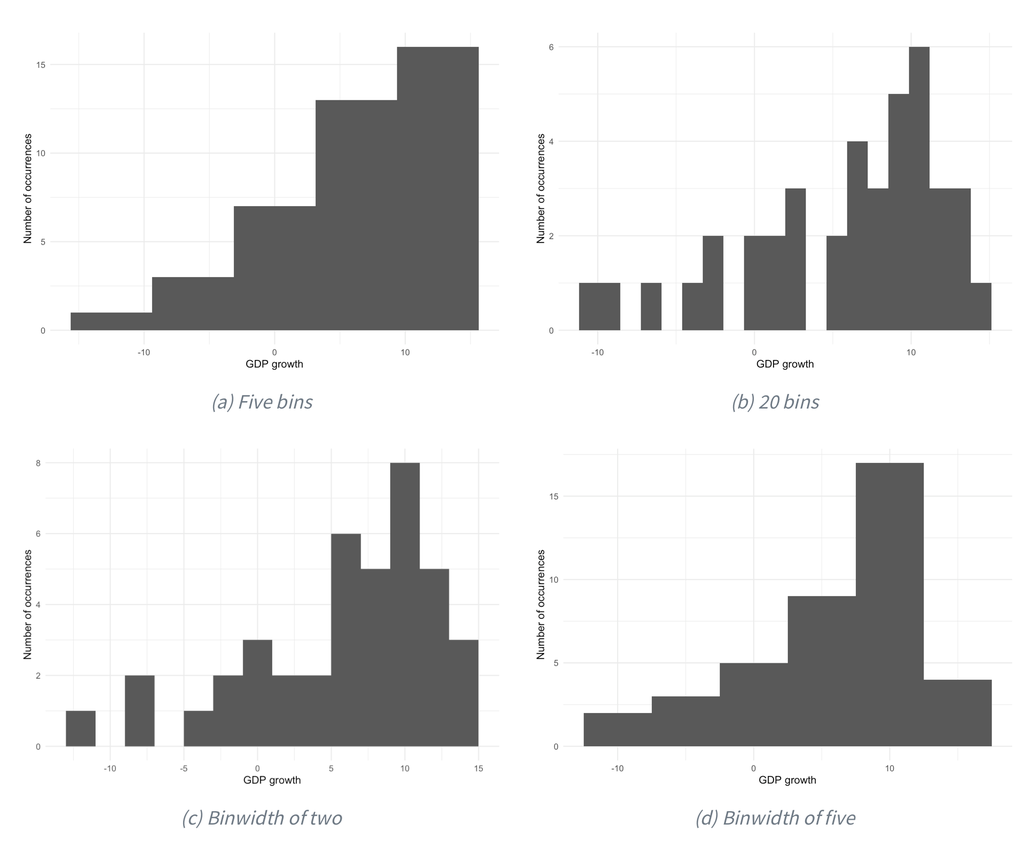

Distribution of GDP growth in Ethiopia (1960-2020)

*Discussion: What is the optimal number of bins?*

## (Don’t use) Boxplots

- Boxplots alone are rarely the best choice because they hide the distribution of data, rather than show it.

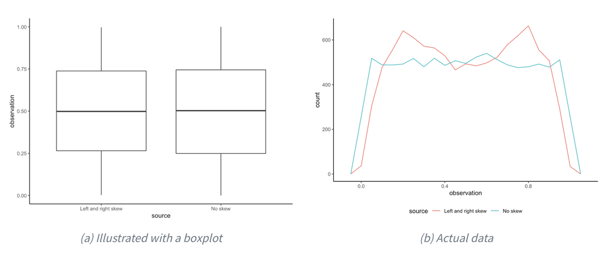

Data drawn from beta distributions with different parameters

*Discussion: When might boxplots be appropriate?*

# Implementation

This section’s slides follow Healy (2026), Chapter 1. All content and figures are from Healy (2026).

## Some data visualizations are better than others

- Undergraduate: What **exactly** do I need in my graph for 10/10?
- Me: It depends.

## What makes bad figures bad

1. Bad taste: Excessive decoration, 3D effects, chart junk.
2. Substantive issues: wrong or misleading data choices.
3. Perceptual problems: angles, area, truncated scales.

## Bad taste

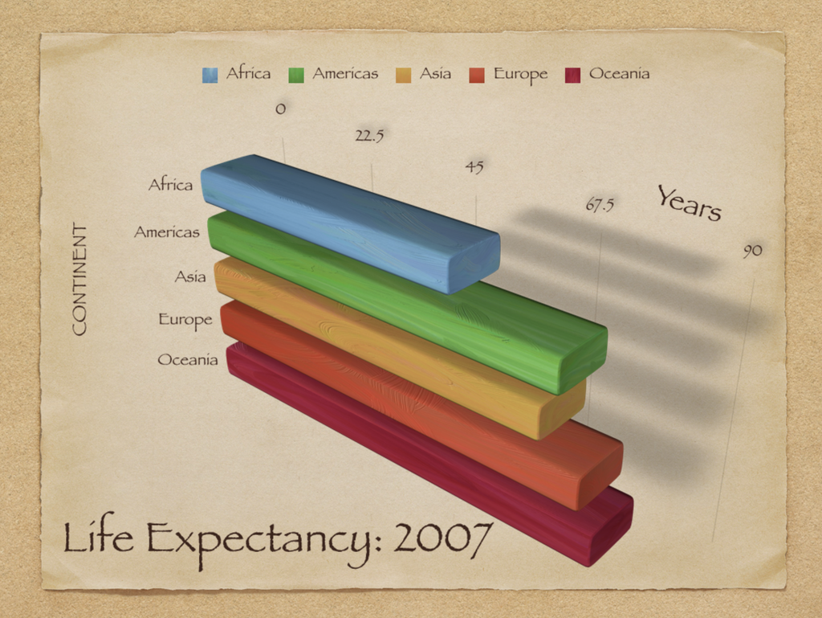

A chart with a considerable amount of junk in it.

*Discussion: What is good and bad about this graph?*

## Bad taste

### What to do

- Maximize the “data-to-ink” ratio.
  - clean up the typeface;
  - remove extraneous colors and backgrounds; and
  - simplify, mute, or delete gridlines, superfluous axis marks, or needless keys and legends.
- But…

*Discussion: What are some exceptions?*

## Bad data

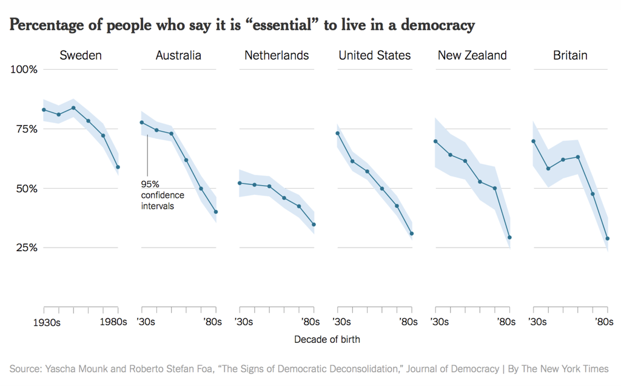

A crisis of faith in democracy? (New York Times.)

*Discussion: What do you take away from this graph?*

## Bad data (cont.)

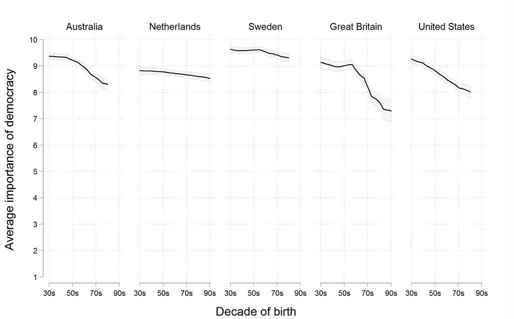

Perhaps the crisis has been overblown. (Erik Voeten.)

## Bad perception

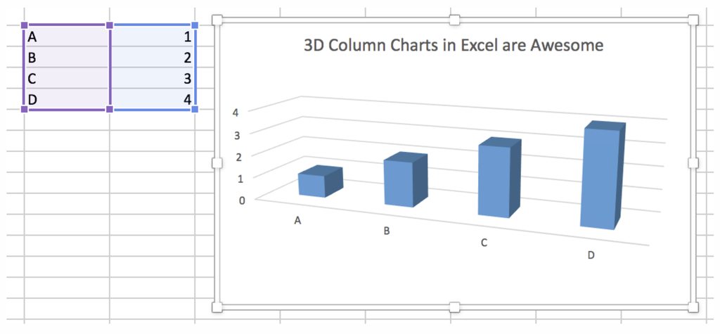

A 3-D Column Chart created in Microsoft Excel for Mac. Although it may seem hard to believe, the values shown in the bars are 1, 2, 3, and 4.)

*Discussion: What do you take away from this graph?*

## Summary

- Focus on who is the audience and what message do we want them to take-away.
- Remove “chartjunk”.
- Use facets or color for group comparisons.
- Plot every observation of every variable.
- Test graphs with your audience.

## References

Armstrong, Zan. 2022. “Stop Aggregating Away the Signal in Your Data.” *The Overflow*, March 3. https://stackoverflow.blog/2022/03/03/stop-aggregating-away-the-signal-in-your-data/.

Bateman, Scott, Regan L. Mandryk, Carl Gutwin, Aaron Genest, David McDine, and Christopher Brooks. 2010. “Useful Junk? The Effects of Visual Embellishment on Comprehension and Memorability of Charts.” *Proceedings of the SIGCHI Conference on Human Factors in Computing Systems*, 2573–82. https://doi.org/10.1145/1753326.1753716.

Bethlehem, R. A. I., J. Seidlitz, S. R. White, et al. 2022. “Brain Charts for the Human Lifespan.” *Nature* 604 (7906): 525–33. https://doi.org/10.1038/s41586-022-04554-y.

Cleveland, William. 1994. *The Elements of Graphing Data*. Hobart Press.

Denby, Lorraine, and Colin Mallows. 2009. “Variations on the Histogram.” *Journal of Computational and Graphical Statistics* 18 (1): 21–31. https://doi.org/10.1198/jcgs.2009.0002.

Friendly, Michael, and Howard Wainer. 2021. *A History of Data Visualization and Graphic Communication*. 1st ed. Harvard University Press.

Healy, Kieran. 2026. *Data Visualization: A Practical Introduction*. 2nd ed. Princeton University Press.

Wasserman, Larry. 2005. *All of Statistics*. Springer.

Weissgerber, Tracey, Natasa Milic, Stacey Winham, and Vesna Garovic. 2015. “Beyond Bar and Line Graphs: Time for a New Data Presentation Paradigm.” *PLoS Biology* 13 (4): e1002128. https://doi.org/10.1371/journal.pbio.1002128.